# Продажа квартир в Санкт-Петербурге — анализ рынка недвижимости

В вашем распоряжении данные сервиса Яндекс.Недвижимость — архив объявлений о продаже квартир в Санкт-Петербурге и соседних населённых пунктов за несколько лет. Нужно научиться определять рыночную стоимость объектов недвижимости. Ваша задача — установить параметры. Это позволит построить автоматизированную систему: она отследит аномалии и мошенническую деятельность.

По каждой квартире на продажу доступны два вида данных. Первые вписаны пользователем, вторые — получены автоматически на основе картографических данных. Например, расстояние до центра, аэропорта, ближайшего парка и водоёма.

### Описание данных

- `airports_nearest` — расстояние до ближайшего аэропорта в метрах (м)
- `balcony` — число балконов
- `ceiling_height` — высота потолков (м)
- `cityCenters_nearest` — расстояние до центра города (м)
- `days_exposition` — сколько дней было размещено объявление (от публикации до снятия)
- `first_day_exposition` — дата публикации
- `floor` — этаж
- `floors_total` — всего этажей в доме
- `is_apartment` — апартаменты (булев тип)
- `kitchen_area` — площадь кухни в квадратных метрах (м²)
- `last_price` — цена на момент снятия с публикации
- `living_area` — жилая площадь в квадратных метрах (м²)
- `locality_name` — название населённого пункта
- `open_plan` — свободная планировка (булев тип)
- `parks_around3000` — число парков в радиусе 3 км
- `parks_nearest` — расстояние до ближайшего парка (м)
- `ponds_around3000` — число водоёмов в радиусе 3 км
- `ponds_nearest` — расстояние до ближайшего водоёма (м)
- `rooms` — число комнат
- `studio` — квартира-студия (булев тип)
- `total_area` — общая площадь квартиры в квадратных метрах (м²)
- `total_images` — число фотографий квартиры в объявлении

### Цель исследования

1. Определить рыночную стоимость объектов недвижимости.
2. Построить автоматизированную систему, которая отследит аномалии и мошенническую деятельность.
3. Установить какие факторы влияют на ценообразование квартир.

### Ход исследования

Данные о недвижимости я получу из файла `/datasets/real_estate_data.csv` О качестве данных ничего не известно. Поэтому перед тем, как приступить к целям исследования, понадобится обзор данных.

Я проверю данные на ошибки и оценю их влияние на исследование. Затем на этапе предобработки я поищу возможность исправить все ошибки данных, которые приведут к искажению конечного результата. Далее создам необходимые столбцы и приступлю к проведению исследовательского анализа.

1. Загрузка данных и подготовка их к анализу
2. Предобработка данных
3. Исследовательский анализ данных
4. Общий вывод

## 1. Загрузка данных и подготовка их к анализу

```python
import pandas as pd
import matplotlib
import matplotlib.pyplot as plt
pd.set_option('display.max_columns', None)
pd.options.display.float_format = '{:.2f}'.format

try:
    data = pd.read_csv('/datasets/real_estate_data.csv', sep='\t')
except:
    data = pd.read_csv('C:/Users/salpa/Downloads/real_estate_data.csv', sep='\t')
```

```python
data.head()
```

|  | total_images | last_price | total_area | first_day_exposition | rooms | ceiling_height | floors_total | living_area | floor | is_apartment | studio | open_plan | kitchen_area | balcony | locality_name | airports_nearest | cityCenters_nearest | parks_around3000 | parks_nearest | ponds_around3000 | ponds_nearest | days_exposition |
| --- | --- | --- | --- | --- | --- | --- | --- | --- | --- | --- | --- | --- | --- | --- | --- | --- | --- | --- | --- | --- | --- | --- |
| 0 | 20 | 13000000.00 | 108.00 | 2019-03-07T00:00:00 | 3 | 2.70 | 16.00 | 51.00 | 8 | NaN | False | False | 25.00 | NaN | Санкт-Петербург | 18863.00 | 16028.00 | 1.00 | 482.00 | 2.00 | 755.00 | NaN |
| 1 | 7 | 3350000.00 | 40.40 | 2018-12-04T00:00:00 | 1 | NaN | 11.00 | 18.60 | 1 | NaN | False | False | 11.00 | 2.00 | посёлок Шушары | 12817.00 | 18603.00 | 0.00 | NaN | 0.00 | NaN | 81.00 |
| 2 | 10 | 5196000.00 | 56.00 | 2015-08-20T00:00:00 | 2 | NaN | 5.00 | 34.30 | 4 | NaN | False | False | 8.30 | 0.00 | Санкт-Петербург | 21741.00 | 13933.00 | 1.00 | 90.00 | 2.00 | 574.00 | 558.00 |
| 3 | 0 | 64900000.00 | 159.00 | 2015-07-24T00:00:00 | 3 | NaN | 14.00 | NaN | 9 | NaN | False | False | NaN | 0.00 | Санкт-Петербург | 28098.00 | 6800.00 | 2.00 | 84.00 | 3.00 | 234.00 | 424.00 |
| 4 | 2 | 10000000.00 | 100.00 | 2018-06-19T00:00:00 | 2 | 3.03 | 14.00 | 32.00 | 13 | NaN | False | False | 41.00 | NaN | Санкт-Петербург | 31856.00 | 8098.00 | 2.00 | 112.00 | 1.00 | 48.00 | 121.00 |

```python
data.info()
```

```
<class 'pandas.core.frame.DataFrame'>
RangeIndex: 23699 entries, 0 to 23698
Data columns (total 22 columns):
 #   Column                Non-Null Count  Dtype
---  ------                --------------  -----
 0   total_images          23699 non-null  int64
 1   last_price            23699 non-null  float64
 2   total_area            23699 non-null  float64
 3   first_day_exposition  23699 non-null  object
 4   rooms                 23699 non-null  int64
 5   ceiling_height        14504 non-null  float64
 6   floors_total          23613 non-null  float64
 7   living_area           21796 non-null  float64
 8   floor                 23699 non-null  int64
 9   is_apartment          2775 non-null   object
 10  studio                23699 non-null  bool
 11  open_plan             23699 non-null  bool
 12  kitchen_area          21421 non-null  float64
 13  balcony               12180 non-null  float64
 14  locality_name         23650 non-null  object
 15  airports_nearest      18157 non-null  float64
 16  cityCenters_nearest   18180 non-null  float64
 17  parks_around3000      18181 non-null  float64
 18  parks_nearest         8079 non-null   float64
 19  ponds_around3000      18181 non-null  float64
 20  ponds_nearest         9110 non-null   float64
 21  days_exposition       20518 non-null  float64
dtypes: bool(2), float64(14), int64(3), object(3)
memory usage: 3.7+ MB
```

```python
data.describe()
```

|  | total_images | last_price | total_area | rooms | ceiling_height | floors_total | living_area | floor | kitchen_area | balcony | airports_nearest | cityCenters_nearest | parks_around3000 | parks_nearest | ponds_around3000 | ponds_nearest | days_exposition |
| --- | --- | --- | --- | --- | --- | --- | --- | --- | --- | --- | --- | --- | --- | --- | --- | --- | --- |
| count | 23699.00 | 23699.00 | 23699.00 | 23699.00 | 14504.00 | 23613.00 | 21796.00 | 23699.00 | 21421.00 | 12180.00 | 18157.00 | 18180.00 | 18181.00 | 8079.00 | 18181.00 | 9110.00 | 20518.00 |
| mean | 9.86 | 6541548.77 | 60.35 | 2.07 | 2.77 | 10.67 | 34.46 | 5.89 | 10.57 | 1.15 | 28793.67 | 14191.28 | 0.61 | 490.80 | 0.77 | 517.98 | 180.89 |
| std | 5.68 | 10887013.27 | 35.65 | 1.08 | 1.26 | 6.60 | 22.03 | 4.89 | 5.91 | 1.07 | 12630.88 | 8608.39 | 0.80 | 342.32 | 0.94 | 277.72 | 219.73 |
| min | 0.00 | 12190.00 | 12.00 | 0.00 | 1.00 | 1.00 | 2.00 | 1.00 | 1.30 | 0.00 | 0.00 | 181.00 | 0.00 | 1.00 | 0.00 | 13.00 | 1.00 |
| 25% | 6.00 | 3400000.00 | 40.00 | 1.00 | 2.52 | 5.00 | 18.60 | 2.00 | 7.00 | 0.00 | 18585.00 | 9238.00 | 0.00 | 288.00 | 0.00 | 294.00 | 45.00 |
| 50% | 9.00 | 4650000.00 | 52.00 | 2.00 | 2.65 | 9.00 | 30.00 | 4.00 | 9.10 | 1.00 | 26726.00 | 13098.50 | 0.00 | 455.00 | 1.00 | 502.00 | 95.00 |
| 75% | 14.00 | 6800000.00 | 69.90 | 3.00 | 2.80 | 16.00 | 42.30 | 8.00 | 12.00 | 2.00 | 37273.00 | 16293.00 | 1.00 | 612.00 | 1.00 | 729.00 | 232.00 |
| max | 50.00 | 763000000.00 | 900.00 | 19.00 | 100.00 | 60.00 | 409.70 | 33.00 | 112.00 | 5.00 | 84869.00 | 65968.00 | 3.00 | 3190.00 | 3.00 | 1344.00 | 1580.00 |

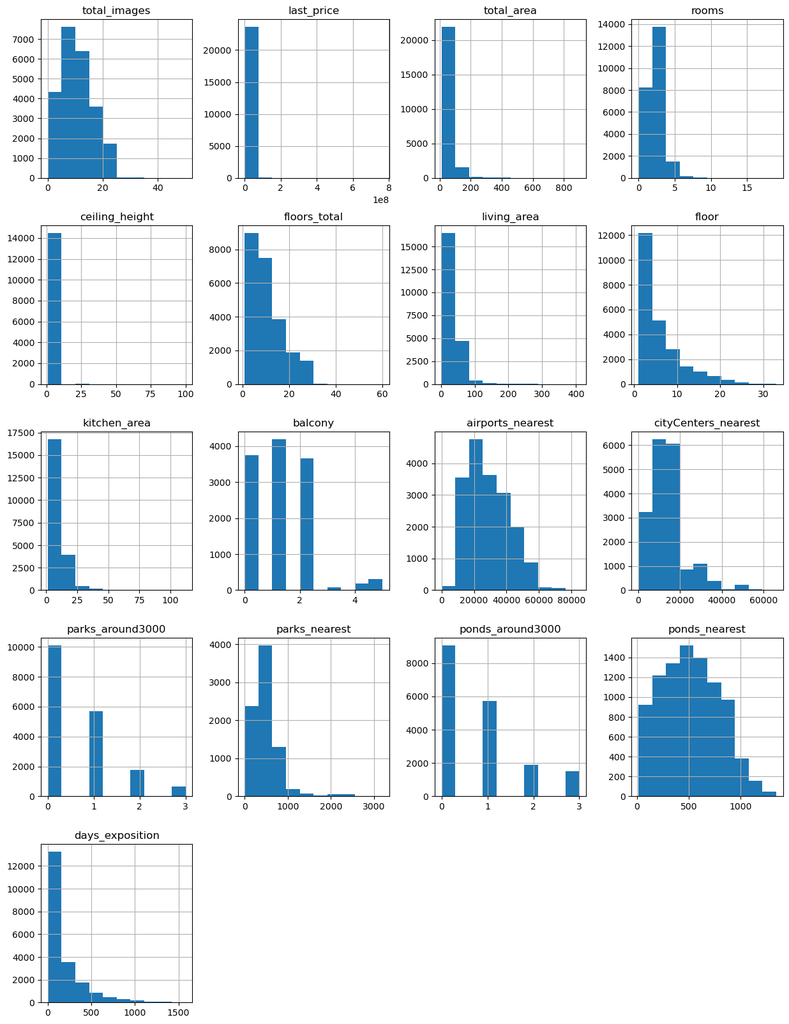

```python
data.hist(figsize=(15, 20))
plt.show()
```

- В таблице 23699 строк. Есть пропуски, аномальные значения и неправильные типы данных.

## 2. Предобработка данных

Сначала ищем и разбираемся с пропусками.

```python
data.isna().sum()
```

```
total_images                0
last_price                  0
total_area                  0
first_day_exposition        0
rooms                       0
ceiling_height           9195
floors_total               86
living_area              1903
floor                       0
is_apartment            20924
studio                      0
open_plan                   0
kitchen_area             2278
balcony                 11519
locality_name              49
airports_nearest         5542
cityCenters_nearest      5519
parks_around3000         5518
parks_nearest           15620
ponds_around3000         5518
ponds_nearest           14589
days_exposition          3181
dtype: int64
```

```python
data = data.dropna(subset=['floors_total']) #удаляем строки с пустыми значениями этажности
data = data.dropna(subset=['locality_name']) #и строки без названия населённого пункта

data['ceiling_height'] = data['ceiling_height'].fillna(data['ceiling_height'].median()) #заполняем пропуски высоты потолков медианой
data['living_area'] = data['living_area'].fillna(data.groupby('rooms')['living_area'].transform('median')) ##заполняем пропуски прощади жилых помещений медианой с группировкой по кол-ву комнат
data['is_apartment'] = data['is_apartment'].fillna(False) #заполняем пропуски указания апартаментов булевым значенем False
data['kitchen_area'] = data['kitchen_area'].fillna(data['kitchen_area'].median()) #заполняем пропуски площади кухни медианой
data['balcony'] = data['balcony'].fillna(0) #заполняем пропуски указания балконов нулями
data['days_exposition'] = data['days_exposition'].fillna(0) #заполняем пропуски количества дней размещения нулями

data.isna().sum() #снова смотрим количество пропусков
```

```
total_images                0
last_price                  0
total_area                  0
first_day_exposition        0
rooms                       0
ceiling_height              0
floors_total                0
living_area                 0
floor                       0
is_apartment                0
studio                      0
open_plan                   0
kitchen_area                0
balcony                     0
locality_name               0
airports_nearest         5524
cityCenters_nearest      5501
parks_around3000         5500
parks_nearest           15535
ponds_around3000         5500
ponds_nearest           14529
days_exposition             0
dtype: int64
```

- Причины появления пропусков в данных могут быть двух типов - случайные и неслучайные, ко второй группе относятся человеческий фактор и техническая ошибка, которые в большей степени, оказывают влияние на появление пропусков. К ним мы и отнесём обработанные нами пропуски в названии населенного пункта, количества этажей в здании, высоте потолков и площади помещений. Указание апартаментов предположительно не вводили, подразумевая, что публикумая квартира апартаментами не является. Также как и балконы не указывали когда их нет. Пропуски же в днях размещения скорее всего означают, что объявление ещё не снято.

Приступаем к типам данных

```python
data['last_price'] = data['last_price'].astype(int) #изменяем тип данных на целые числа
data['first_day_exposition']= pd.to_datetime(data['first_day_exposition'], format='%Y-%m-%dT%H:%M:%S') #изменяем строку на тип данных даты и времени
data['floors_total'] = data['floors_total'].astype(int) #изменяем тип данных на целые числа
data['is_apartment'] = data['is_apartment'].astype(bool) #изменяем тип данных на булевые значения
data['balcony'] = data['balcony'].astype(int) #изменяем тип данных на целые числа
data['days_exposition'] = data['days_exposition'].astype(int) #изменяем тип данных на целые числа

data.info() #проверяем изменения типов данных
print(data.head()) #визульный контроль тоже полезен
```

```
<class 'pandas.core.frame.DataFrame'>
Int64Index: 23565 entries, 0 to 23698
Data columns (total 22 columns):
 #   Column                Non-Null Count  Dtype
---  ------                --------------  -----
 0   total_images          23565 non-null  int64
 1   last_price            23565 non-null  int32
 2   total_area            23565 non-null  float64
 3   first_day_exposition  23565 non-null  datetime64[ns]
 4   rooms                 23565 non-null  int64
 5   ceiling_height        23565 non-null  float64
 6   floors_total          23565 non-null  int32
 7   living_area           23565 non-null  float64
 8   floor                 23565 non-null  int64
 9   is_apartment          23565 non-null  bool
```

[output cut: 48 more lines]

- В ряде столбцов мы изменили типы данных на целые числа потому что по смыслу в них не может быть дробной составляющей - количество этажей в здании, число балконов и количество дней объявления в публикации. В столбце с последней ценой отбросили копейки (а точнее нули после точки). Привели в порядок столбец с датой публикации объявления и вернули столбцу сообщающему нам апартаменты ли искомая недвижимость булевый тип данных.

Теперь проведём работу с дубликатами и аномалиями.

```python
data.duplicated().sum() #проверяем есть ли явные дубликаты в датафрейме
```

```
0
```

```python
data['locality_name'] = data['locality_name'].str.replace('ё','е', regex=True) #сразу заменяем букву "ё" на "е" в названиях населённых пунктов (Артём во мне негодует, но что поделать)
data['locality_name'].unique() #смотрим уникальный список населённых пунктов
```

```
array(['Санкт-Петербург', 'поселок Шушары', 'городской поселок Янино-1',
       'поселок Парголово', 'поселок Мурино', 'Ломоносов', 'Сертолово',
       'Петергоф', 'Пушкин', 'деревня Кудрово', 'Коммунар', 'Колпино',
       'поселок городского типа Красный Бор', 'Гатчина',
       'деревня Федоровское', 'Выборг', 'Кронштадт', 'Кировск',
       'деревня Новое Девяткино', 'поселок Металлострой',
       'поселок городского типа Лебяжье',
       'поселок городского типа Сиверский', 'поселок Молодцово',
       'поселок городского типа Кузьмоловский',
       'садовое товарищество Новая Ропша', 'Павловск',
       'деревня Пикколово', 'Всеволожск', 'Волхов', 'Кингисепп',
       'Приозерск', 'Сестрорецк', 'деревня Куттузи', 'поселок Аннино',
       'поселок городского типа Ефимовский', 'поселок Плодовое',
       'деревня Заклинье', 'поселок Торковичи', 'поселок Первомайское',
       'Красное Село', 'поселок Понтонный', 'Сясьстрой', 'деревня Старая',
       'деревня Лесколово', 'поселок Новый Свет', 'Сланцы',
       'село Путилово', 'Ивангород', 'Мурино', 'Шлиссельбург',
       'Никольское', 'Зеленогорск', 'Сосновый Бор', 'деревня Оржицы',
       'деревня Кальтино', 'Кудрово', 'поселок Романовка',
       'поселок Бугры', 'поселок городского типа Рощино', 'Кириши',
       'Луга', 'Волосово', 'Отрадное', 'село Павлово', 'поселок Оредеж',
       'село Копорье', 'поселок Молодежное', 'Тихвин', 'поселок Победа',
       'деревня Нурма', 'поселок городского типа Синявино', 'Тосно',
       'поселок Стрельна', 'Бокситогорск', 'поселок Александровская',
       'деревня Лопухинка', 'Пикалево', 'поселок Терволово',
       'поселок городского типа Советский', 'Подпорожье',
       'поселок Петровское', 'поселок городского типа Токсово',
       'поселок Сельцо', 'поселок городского типа Вырица',
       'деревня Кипень', 'деревня Келози', 'деревня Вартемяги',
       'поселок Тельмана', 'поселок Севастьяново',
       'городской поселок Большая Ижора', 'городской поселок Павлово',
       'деревня Агалатово', 'поселок Новогорелово',
       'городской поселок Лесогорский', 'деревня Лаголово',
       'поселок Цвелодубово', 'поселок городского типа Рахья',
       'деревня Белогорка', 'поселок Заводской',
       'городской поселок Новоселье', 'деревня Большие Колпаны',
       'деревня Горбунки', 'деревня Батово', 'деревня Заневка',
       'деревня Иссад', 'Приморск', 'городской поселок Федоровское',
       'деревня Мистолово', 'Новая Ладога', 'поселок Зимитицы',
       'поселок Барышево', 'деревня Разметелево',
```

[output cut: 79 more lines]

```
       'деревня Ям-Тесово', 'деревня Раздолье', 'деревня Терпилицы',
       'поселок Шугозеро', 'деревня Ваганово', 'поселок Пушное',
       'садовое товарищество Садко', 'поселок Усть-Ижора',
       'деревня Выскатка', 'городской поселок Свирьстрой',
       'поселок Громово', 'деревня Кисельня', 'деревня Трубников Бор',
       'поселок Калитино', 'поселок Высокоключевой',
       'садовое товарищество Приладожский',
       'поселок Пансионат Зеленый Бор', 'деревня Ненимяки',
       'деревня Снегиревка', 'деревня Рапполово', 'деревня Пустынка',
       'поселок Рабитицы', 'деревня Большой Сабск', 'деревня Русско',
       'деревня Лупполово', 'деревня Большое Рейзино',
       'деревня Малая Романовка', 'поселок Дружноселье', 'поселок Пчевжа',
       'поселок Володарское', 'деревня Нижняя',
       'коттеджный поселок Лесное', 'деревня Тихковицы',
       'деревня Борисова Грива', 'поселок Дзержинского'], dtype=object)
```

```python
data['locality_name'] = data['locality_name'].replace(['городской поселок ', 'поселок городского типа ', 'коттеджный поселок ', 'поселок ', 'деревня ', 'садовое товарищество ', 'село ', 'садоводческое некоммерческое товарищество ', 'станции ', 'при железнодорожной '], '', regex=True) #убираем виды населённых пунтов, оставляем только топонимы
data['locality_name'].unique() #проверяем список
```

```
array(['Санкт-Петербург', 'Шушары', 'Янино-1', 'Парголово', 'Мурино',
       'Ломоносов', 'Сертолово', 'Петергоф', 'Пушкин', 'Кудрово',
       'Коммунар', 'Колпино', 'Красный Бор', 'Гатчина', 'Федоровское',
       'Выборг', 'Кронштадт', 'Кировск', 'Новое Девяткино',
       'Металлострой', 'Лебяжье', 'Сиверский', 'Молодцово',
       'Кузьмоловский', 'Новая Ропша', 'Павловск', 'Пикколово',
       'Всеволожск', 'Волхов', 'Кингисепп', 'Приозерск', 'Сестрорецк',
       'Куттузи', 'Аннино', 'Ефимовский', 'Плодовое', 'Заклинье',
       'Торковичи', 'Первомайское', 'Красное Село', 'Понтонный',
       'Сясьстрой', 'Старая', 'Лесколово', 'Новый Свет', 'Сланцы',
       'Путилово', 'Ивангород', 'Шлиссельбург', 'Никольское',
       'Зеленогорск', 'Сосновый Бор', 'Оржицы', 'Кальтино', 'Романовка',
       'Бугры', 'Рощино', 'Кириши', 'Луга', 'Волосово', 'Отрадное',
       'Павлово', 'Оредеж', 'Копорье', 'Молодежное', 'Тихвин', 'Победа',
       'Нурма', 'Синявино', 'Тосно', 'Стрельна', 'Бокситогорск',
       'Александровская', 'Лопухинка', 'Пикалево', 'Терволово',
       'Советский', 'Подпорожье', 'Петровское', 'Токсово', 'Сельцо',
       'Вырица', 'Кипень', 'Келози', 'Вартемяги', 'Тельмана',
       'Севастьяново', 'Большая Ижора', 'Агалатово', 'Новогорелово',
       'Лесогорский', 'Лаголово', 'Цвелодубово', 'Рахья', 'Белогорка',
       'Заводской', 'Новоселье', 'Большие Колпаны', 'Горбунки', 'Батово',
       'Заневка', 'Иссад', 'Приморск', 'Мистолово', 'Новая Ладога',
       'Зимитицы', 'Барышево', 'Разметелево', 'имени Свердлова', 'Пеники',
       'Рябово', 'Пудомяги', 'Корнево', 'Низино', 'Бегуницы', 'Поляны',
       'Мга', 'Елизаветино', 'Кузнечное', 'Колтуши', 'Запорожское',
       'Гостилицы', 'Малое Карлино', 'Мичуринское', 'имени Морозова',
       'Песочный', 'Сосново', 'Аро', 'Ильичево', 'Тайцы', 'Малое Верево',
       'Извара', 'Вещево', 'Паша', 'Калитино', 'Ульяновка', 'Чудской Бор',
       'Дубровка', 'Мины', 'Войсковицы', 'Коркино', 'Ропша',
       'Приладожский', 'Щеглово', 'Гаврилово', 'Лодейное Поле',
       'Рабитицы', 'Никольский', 'Кузьмолово', 'Малые Колпаны',
       'Петро-Славянка', 'Назия', 'Репино', 'Углово', 'Старая Малукса',
       'Меньково', 'Старые Бегуницы', 'Саперный', 'Семрино', 'Глажево',
       'Кобринское', 'Гарболово', 'Юкки', 'Приветнинское', 'Мануйлово',
       'Пчева', 'Цвылево', 'Мельниково', 'Пудость', 'Усть-Луга',
       'Светогорск', 'Любань', 'Селезнево', 'Каменногорск', 'Кривко',
       'Глебычево', 'Парицы', 'Жилпоселок', 'Войскорово', 'Стеклянный',
       'Важины', 'Мыза-Ивановка', 'Русско-Высоцкое', 'Форносово',
       'Старая Ладога', 'Житково', 'Виллози', 'Лампово', 'Шпаньково',
       'Лаврики', 'Сумино', 'Возрождение', 'Старосиверская', 'Кикерино',
```

[output cut: 10 more lines]

```
       'Вознесенье', 'Разбегаево', 'Гладкое', 'Тесово-4', 'Бор',
       'Коробицыно', 'Большая Вруда', 'Курковицы', 'Кобралово',
       'Суоранда', 'Кондратьево', 'Счастье', 'Реброво', 'Тойворово',
       'Семиозерье', 'Лесное', 'Совхозный', 'Ленинское', 'Суйда',
       'Нижние Осельки', 'Свирь', 'Перово', 'Высоцк', 'Шум', 'Котельский',
       'Лужайка', 'Большая Пустомержа', 'Красносельское', 'Вахнова Кара',
       'Пижма', 'Кивеннапа Север', 'Ромашки', 'Каськово', 'Куровицы',
       'Плоское', 'Кирпичное', 'Ям-Тесово', 'Раздолье', 'Терпилицы',
       'Шугозеро', 'Ваганово', 'Пушное', 'Садко', 'Усть-Ижора',
       'Выскатка', 'Свирьстрой', 'Кисельня', 'Трубников Бор',
       'Высокоключевой', 'Пансионат Зеленый Бор', 'Ненимяки',
       'Снегиревка', 'Рапполово', 'Пустынка', 'Большой Сабск', 'Русско',
       'Лупполово', 'Большое Рейзино', 'Малая Романовка', 'Дружноселье',
       'Пчевжа', 'Володарское', 'Нижняя', 'Тихковицы', 'Борисова Грива',
       'Дзержинского'], dtype=object)
```

```python
data[data['ceiling_height'] >= 10] #проверяем аномалии в высоте потолков
```

|  | total_images | last_price | total_area | first_day_exposition | rooms | ceiling_height | floors_total | living_area | floor | is_apartment | studio | open_plan | kitchen_area | balcony | locality_name | airports_nearest | cityCenters_nearest | parks_around3000 | parks_nearest | ponds_around3000 | ponds_nearest | days_exposition |
| --- | --- | --- | --- | --- | --- | --- | --- | --- | --- | --- | --- | --- | --- | --- | --- | --- | --- | --- | --- | --- | --- | --- |
| 355 | 17 | 3600000 | 55.20 | 2018-07-12 | 2 | 25.00 | 5 | 32.00 | 2 | False | False | False | 9.10 | 2 | Гатчина | NaN | NaN | NaN | NaN | NaN | NaN | 259 |
| 3148 | 14 | 2900000 | 75.00 | 2018-11-12 | 3 | 32.00 | 3 | 53.00 | 2 | False | False | False | 8.00 | 0 | Волхов | NaN | NaN | NaN | NaN | NaN | NaN | 0 |
| 4643 | 0 | 4300000 | 45.00 | 2018-02-01 | 2 | 25.00 | 9 | 30.00 | 2 | False | False | False | 7.00 | 1 | Санкт-Петербург | 12016.00 | 13256.00 | 1.00 | 658.00 | 1.00 | 331.00 | 181 |
| 4876 | 7 | 3000000 | 25.00 | 2017-09-27 | 0 | 27.00 | 25 | 17.00 | 17 | False | False | True | 9.10 | 2 | Мурино | NaN | NaN | NaN | NaN | NaN | NaN | 28 |
| 5076 | 0 | 3850000 | 30.50 | 2018-10-03 | 1 | 24.00 | 5 | 19.50 | 1 | True | False | False | 5.50 | 0 | Санкт-Петербург | 29686.00 | 8389.00 | 3.00 | 397.00 | 1.00 | 578.00 | 7 |
| 5246 | 0 | 2500000 | 54.00 | 2017-10-13 | 2 | 27.00 | 5 | 30.00 | 3 | False | False | False | 9.00 | 2 | Мины | NaN | NaN | NaN | NaN | NaN | NaN | 540 |
| 5669 | 4 | 4400000 | 50.00 | 2017-08-08 | 2 | 26.00 | 9 | 21.30 | 3 | False | False | False | 7.00 | 2 | Санкт-Петербург | 28981.00 | 10912.00 | 1.00 | 305.00 | 0.00 | NaN | 267 |
| 5807 | 17 | 8150000 | 80.00 | 2019-01-09 | 2 | 27.00 | 36 | 41.00 | 13 | False | False | False | 12.00 | 5 | Санкт-Петербург | 18732.00 | 20444.00 | 0.00 | NaN | 3.00 | 80.00 | 38 |
| 6246 | 6 | 3300000 | 44.40 | 2019-03-25 | 2 | 25.00 | 5 | 31.30 | 5 | False | False | False | 5.70 | 0 | Кронштадт | 68923.00 | 50649.00 | 1.00 | 417.00 | 2.00 | 73.00 | 0 |
| 9379 | 5 | 3950000 | 42.00 | 2017-03-26 | 3 | 25.00 | 5 | 30.00 | 2 | False | False | False | 5.20 | 0 | Санкт-Петербург | 11647.00 | 13581.00 | 0.00 | NaN | 0.00 | NaN | 0 |
| 10773 | 8 | 3800000 | 58.00 | 2017-10-13 | 2 | 27.00 | 10 | 30.10 | 3 | False | False | False | 8.10 | 2 | Мурино | NaN | NaN | NaN | NaN | NaN | NaN | 71 |
| 11285 | 0 | 1950000 | 37.00 | 2019-03-20 | 1 | 25.00 | 5 | 17.00 | 4 | False | False | False | 9.00 | 2 | Луга | NaN | NaN | NaN | NaN | NaN | NaN | 18 |
| 14382 | 9 | 1700000 | 35.00 | 2015-12-04 | 1 | 25.00 | 5 | 20.00 | 2 | False | False | False | 8.00 | 1 | Новый Свет | NaN | NaN | NaN | NaN | NaN | NaN | 206 |
| 15061 | 19 | 5600000 | 56.40 | 2018-05-11 | 2 | 14.00 | 14 | 32.40 | 5 | False | False | False | 9.10 | 2 | Санкт-Петербург | 14814.00 | 13610.00 | 0.00 | NaN | 0.00 | NaN | 315 |
| 17496 | 15 | 6700000 | 92.90 | 2019-02-19 | 3 | 20.00 | 17 | 53.20 | 14 | False | False | False | 12.00 | 5 | Санкт-Петербург | 16295.00 | 15092.00 | 1.00 | 967.00 | 0.00 | NaN | 0 |
| 17857 | 1 | 3900000 | 56.00 | 2017-12-22 | 3 | 27.00 | 5 | 33.00 | 4 | False | False | False | 9.10 | 0 | Санкт-Петербург | 41030.00 | 15543.00 | 0.00 | NaN | 0.00 | NaN | 73 |
| 18545 | 6 | 3750000 | 43.00 | 2019-03-18 | 2 | 25.00 | 5 | 29.00 | 3 | False | False | False | 9.10 | 0 | Санкт-Петербург | 27054.00 | 8033.00 | 1.00 | 540.00 | 0.00 | NaN | 12 |
| 20478 | 11 | 8000000 | 45.00 | 2017-07-18 | 1 | 27.00 | 4 | 22.00 | 2 | False | False | False | 10.00 | 1 | Санкт-Петербург | 18975.00 | 3246.00 | 0.00 | NaN | 3.00 | 449.00 | 429 |
| 20507 | 12 | 5950000 | 60.00 | 2018-02-19 | 2 | 22.60 | 14 | 35.00 | 11 | False | False | False | 13.00 | 1 | Санкт-Петербург | 27028.00 | 12570.00 | 0.00 | NaN | 0.00 | NaN | 40 |
| 21377 | 19 | 4900000 | 42.00 | 2017-04-18 | 1 | 27.50 | 24 | 37.70 | 19 | False | False | False | 11.00 | 2 | Санкт-Петербург | 42742.00 | 9760.00 | 0.00 | NaN | 0.00 | NaN | 61 |
| 21824 | 20 | 2450000 | 44.00 | 2019-02-12 | 2 | 27.00 | 2 | 38.00 | 2 | False | False | False | 8.60 | 2 | Большая Ижора | NaN | NaN | NaN | NaN | NaN | NaN | 0 |
| 22309 | 20 | 5300000 | 45.00 | 2017-09-30 | 1 | 10.30 | 16 | 15.50 | 15 | False | False | False | 9.10 | 0 | Санкт-Петербург | 36353.00 | 11936.00 | 2.00 | 440.00 | 2.00 | 450.00 | 136 |
| 22336 | 19 | 9999000 | 92.40 | 2019-04-05 | 2 | 32.00 | 6 | 55.50 | 5 | False | False | False | 16.50 | 4 | Санкт-Петербург | 18838.00 | 3506.00 | 0.00 | NaN | 3.00 | 511.00 | 0 |
| 22869 | 0 | 15000000 | 25.00 | 2018-07-25 | 1 | 100.00 | 5 | 14.00 | 5 | True | False | False | 11.00 | 5 | Санкт-Петербург | 34963.00 | 8283.00 | 1.00 | 223.00 | 3.00 | 30.00 | 19 |
| 22938 | 14 | 4000000 | 98.00 | 2018-03-15 | 4 | 27.00 | 2 | 73.00 | 2 | True | False | False | 9.00 | 1 | Нижняя | NaN | NaN | NaN | NaN | NaN | NaN | 27 |

```python
data.loc[data['ceiling_height'] >= 10, 'ceiling_height'] = data['ceiling_height'].median() #заменяем всё, что больше 10 метров медианой
data['ceiling_height'].describe() #смотрим описательную статистику
```

```
count   23565.00
mean        2.70
std         0.23
min         1.00
25%         2.60
50%         2.65
75%         2.70
max         8.30
Name: ceiling_height, dtype: float64
```

```python
data[(data['last_price'] < 100000) | (data['last_price'] > 500000000)] #проверяем аномальные цены
```

|  | total_images | last_price | total_area | first_day_exposition | rooms | ceiling_height | floors_total | living_area | floor | is_apartment | studio | open_plan | kitchen_area | balcony | locality_name | airports_nearest | cityCenters_nearest | parks_around3000 | parks_nearest | ponds_around3000 | ponds_nearest | days_exposition |
| --- | --- | --- | --- | --- | --- | --- | --- | --- | --- | --- | --- | --- | --- | --- | --- | --- | --- | --- | --- | --- | --- | --- |
| 8793 | 7 | 12190 | 109.00 | 2019-03-20 | 2 | 2.75 | 25 | 32.00 | 25 | False | False | False | 40.50 | 0 | Санкт-Петербург | 36421.00 | 9176.00 | 1.00 | 805.00 | 0.00 | NaN | 8 |
| 12971 | 19 | 763000000 | 400.00 | 2017-09-30 | 7 | 2.65 | 10 | 250.00 | 10 | False | False | False | 9.10 | 2 | Санкт-Петербург | 25108.00 | 3956.00 | 1.00 | 530.00 | 3.00 | 756.00 | 33 |

```python
data = data.drop(labels = [8793, 12971], axis = 0) #убираем строки под номером 8793 и 12971
data.reset_index() #сбрасываем индексы в датафрейме
data.describe()
```

|  | total_images | last_price | total_area | rooms | ceiling_height | floors_total | living_area | floor | kitchen_area | balcony | airports_nearest | cityCenters_nearest | parks_around3000 | parks_nearest | ponds_around3000 | ponds_nearest | days_exposition |
| --- | --- | --- | --- | --- | --- | --- | --- | --- | --- | --- | --- | --- | --- | --- | --- | --- | --- |
| count | 23563.00 | 23563.00 | 23563.00 | 23563.00 | 23563.00 | 23563.00 | 23563.00 | 23563.00 | 23563.00 | 23563.00 | 18039.00 | 18062.00 | 18063.00 | 8028.00 | 18063.00 | 9035.00 | 23563.00 |
| mean | 9.88 | 6508231.58 | 60.31 | 2.07 | 2.70 | 10.68 | 34.32 | 5.88 | 10.42 | 0.59 | 28796.86 | 14193.50 | 0.61 | 490.54 | 0.77 | 518.26 | 156.43 |
| std | 5.68 | 9734966.44 | 35.59 | 1.08 | 0.23 | 6.59 | 21.68 | 4.87 | 5.63 | 0.96 | 12633.04 | 8613.41 | 0.80 | 341.60 | 0.94 | 278.01 | 213.52 |
| min | 0.00 | 430000.00 | 12.00 | 0.00 | 1.00 | 1.00 | 2.00 | 1.00 | 1.30 | 0.00 | 0.00 | 181.00 | 0.00 | 1.00 | 0.00 | 13.00 | 0.00 |
| 25% | 6.00 | 3400000.00 | 40.00 | 1.00 | 2.60 | 5.00 | 18.40 | 2.00 | 7.30 | 0.00 | 18561.00 | 9238.00 | 0.00 | 288.00 | 0.00 | 293.00 | 22.00 |
| 50% | 9.00 | 4646000.00 | 52.00 | 2.00 | 2.65 | 9.00 | 30.30 | 4.00 | 9.10 | 0.00 | 26757.00 | 13098.50 | 0.00 | 455.00 | 1.00 | 503.00 | 73.00 |
| 75% | 14.00 | 6790000.00 | 69.70 | 3.00 | 2.70 | 16.00 | 42.70 | 8.00 | 11.41 | 1.00 | 37273.00 | 16285.00 | 1.00 | 612.00 | 1.00 | 730.00 | 198.00 |
| max | 50.00 | 420000000.00 | 900.00 | 19.00 | 8.30 | 60.00 | 409.70 | 33.00 | 112.00 | 5.00 | 84869.00 | 65968.00 | 3.00 | 3190.00 | 3.00 | 1344.00 | 1580.00 |

- Сначала была проведена проверка на явные дубликаты, которых не оказалось.
- Потом мы приступили к неявным дубликатам и начали со строк в столбце с названиями населённых пунктов.
- Проверили и исправили аномалии с высотой потолков, где очевидно были вбиты сантиметры, а не метры.
- Также убрали строки с аномально низкой и высокой ценой

Посчитаем и добавим в таблицу новые столбцы.

```python
data['square_price'] = data['last_price'] / data['total_area'] #добавляем столбец с ценой квадратного метра
data['weekday_exposition'] = pd.DatetimeIndex(data['first_day_exposition']).dayofweek #добавляем столбец с днём недели публикации объявления
data['month_exposition'] = pd.DatetimeIndex(data['first_day_exposition']).month #добавляем столбец с месяцем публикации объявления
data['year_exposition'] = pd.DatetimeIndex(data['first_day_exposition']).year #добавляем столбец с годом публикации объявления

def floor_type(floor):
    if floor['floor'] == 1:
        return 'первый'
    elif floor['floor'] == floor['floors_total']:
        return 'последний'
    else:
        return 'другой'
data['floor_type'] = data.apply(floor_type, axis = 1) #распределяем в новый столбец тип этажа квартиры с помощью функции

data['cityCenters_km'] = (data['cityCenters_nearest'] / 1000).round() #добавляем столбец с расстоянием до центра города в километрах
```

## 3. Исследовательский анализ данных

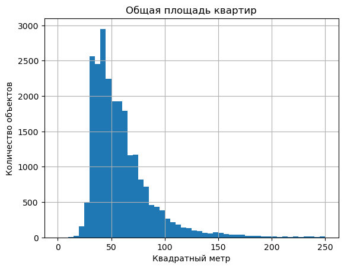

```python
data['total_area'].hist(bins=50, range=(0, 250))
plt.title('Общая площадь квартир')
plt.ylabel('Количество объектов')
plt.xlabel('Квадратный метр')
plt.show()
```

- Основная масса квартир общей площадью меньше 70 метров. Медианное значение - 52 метра.

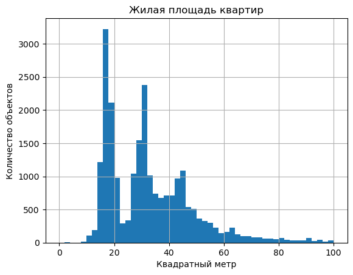

```python
data['living_area'].hist(bins=50, range=(0, 100))
plt.title('Жилая площадь квартир')
plt.ylabel('Количество объектов')
plt.xlabel('Квадратный метр')
plt.show()
```

- Самые популярные варианты жилых помещений - от 10 до 50 метров. Средний метраж - 34 метра. На гистограмме заметны пики, очевидно означающие разбивку по количеству комнат - 1, 2 и 3.

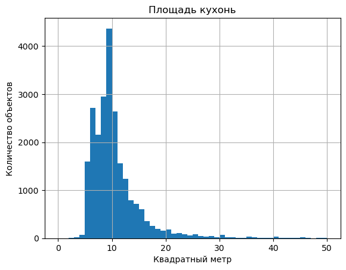

```python
data['kitchen_area'].hist(bins=50, range=(0, 50))
plt.title('Площадь кухонь')
plt.ylabel('Количество объектов')
plt.xlabel('Квадратный метр')
plt.show()
```

- Метраж кухонь в основном от 5 до 15 метров. Больше 30 почти нет.

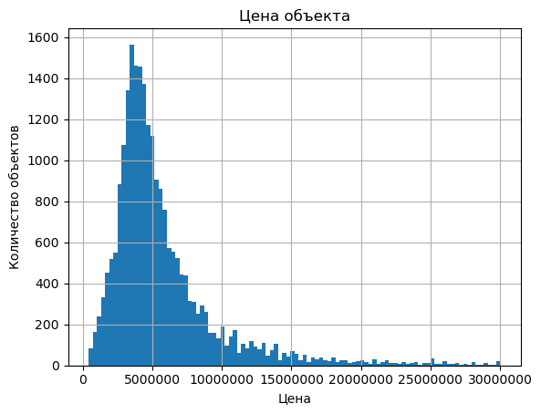

```python
data['last_price'][data['last_price'] <= 30000000].hist(bins=100)
plt.ticklabel_format(useOffset=False, style='plain'); #подписи оси в миллионах
plt.title('Цена объекта')
plt.ylabel('Количество объектов')
plt.xlabel('Цена')
plt.show()
```

- Разброс популярных цен - от 3 до 12 млн с пиком в 4 млн.

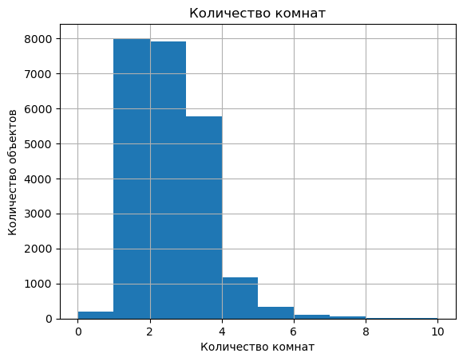

```python
data['rooms'].hist(bins=10, range=(0, 10))
plt.title('Количество комнат')
plt.ylabel('Количество объектов')
plt.xlabel('Количество комнат')
plt.show()
```

- Основные выставляемые квартиры - однокомнатные, двухкомнатные и трёхкомнатные. Остальных сильно меньше.

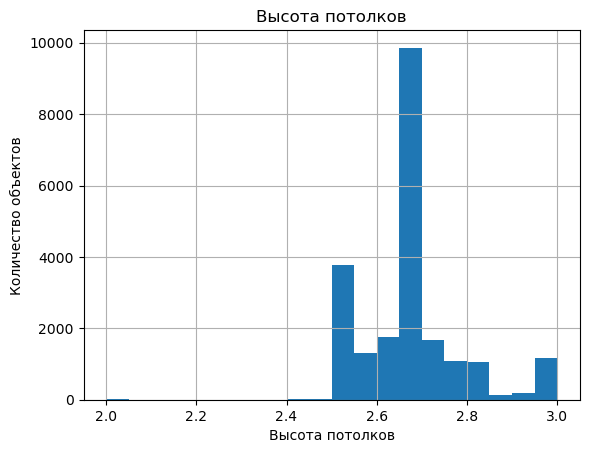

```python
data['ceiling_height'].hist(bins=20, range=(2, 3))
plt.title('Высота потолков')
plt.ylabel('Количество объектов')
plt.xlabel('Высота потолков')
plt.show()
```

- Пиковый разброс высоты потолков - от 2,5 до 2,9 метров.

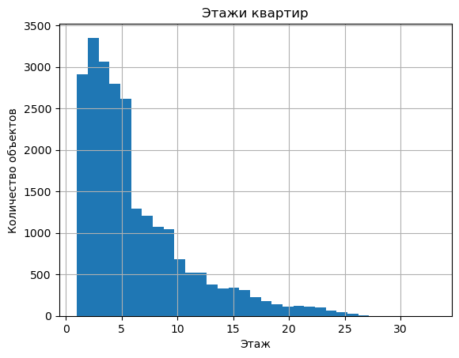

```python
data['floor'].hist(bins=33, range=(1, 33))
plt.title('Этажи квартир')
plt.ylabel('Количество объектов')
plt.xlabel('Этаж')
plt.show()
```

- Самая популярная этажность - до 5. Найти квартиру с этажом 6 и выше сложнее, но есть варианты и до 25.

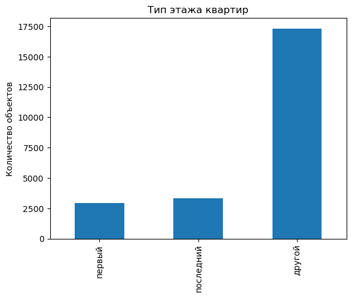

```python
data['floor_type'].value_counts(ascending=True).plot(kind='bar')
plt.title('Тип этажа квартир')
plt.ylabel('Количество объектов')
plt.show()
```

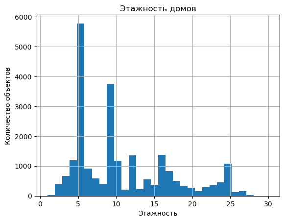

```python
data['floors_total'].hist(bins=30, range=(1, 30))
plt.title('Этажность домов')
plt.ylabel('Количество объектов')
plt.xlabel('Этажность')
plt.show()
```

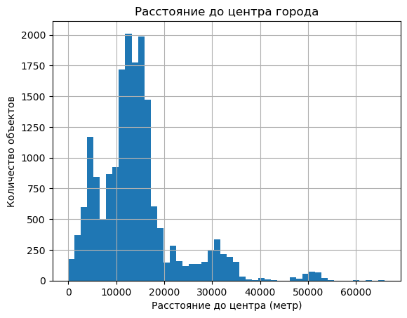

```python
data['cityCenters_nearest'].hist(bins=50, range=(0, 66000))
plt.title('Расстояние до центра города')
plt.ylabel('Количество объектов')
plt.xlabel('Расстояние до центра (метр)')
plt.show()
```

- Расстояние от центра скорее всего будет от 10 до 15 км, что подтверждает пик на гистграмме и медиана в 13 км.

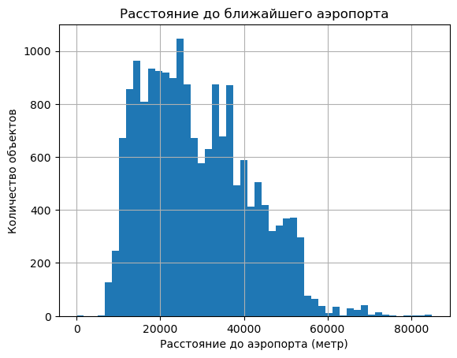

```python
data['airports_nearest'].hist(bins=50, range=(0, 85000))
plt.title('Расстояние до ближайшего аэропорта')
plt.ylabel('Количество объектов')
plt.xlabel('Расстояние до аэропорта (метр)')
plt.show()
```

- Аэропорт будет скорее ближе чем дальше.

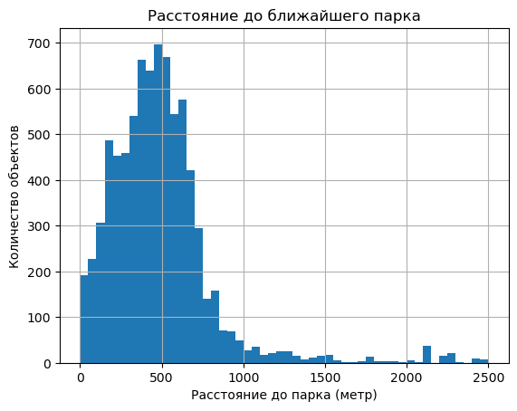

```python
data['parks_nearest'].hist(bins=50, range=(0, 2500))
plt.title('Расстояние до ближайшего парка')
plt.ylabel('Количество объектов')
plt.xlabel('Расстояние до парка (метр)')
plt.show()
```

- Парк находиться будет в среднем на расстоянии 500 метров от квартиры.

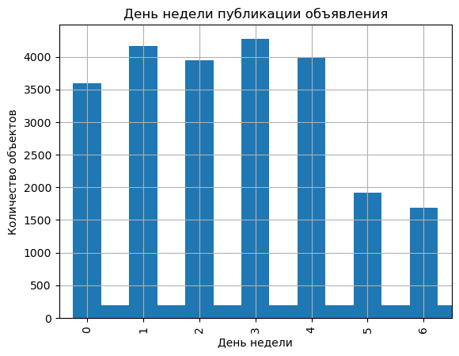

```python
data['weekday_exposition'].value_counts().sort_index().plot(kind='bar')
data['parks_nearest'].hist(bins=50, range=(0, 2500))
#plt.xticks(['Понедельник', 'Вторник', 'Среда', 'Четверг', 'Пятница', 'Суббота', 'Воскресенье'])
plt.title('День недели публикации объявления')
plt.ylabel('Количество объектов')
plt.xlabel('День недели')
plt.show()
```

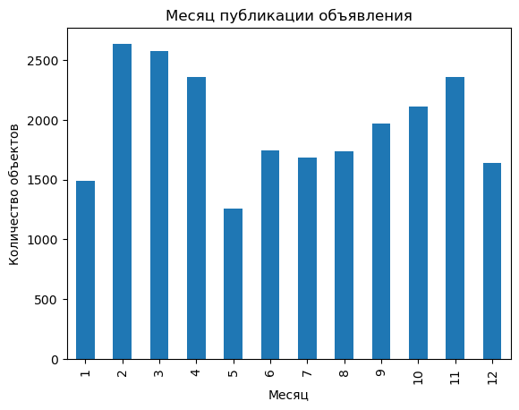

```python
data['month_exposition'].value_counts().sort_index().plot(kind='bar')
plt.title('Месяц публикации объявления')
plt.ylabel('Количество объектов')
plt.xlabel('Месяц')
plt.show()
```

### Как быстро продавались квартиры

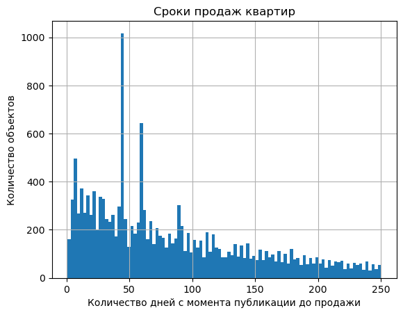

```python
data['days_exposition'].hist(bins=100, range=(1, 250)) #гистограмма скорости продажи квартир
plt.title('Сроки продаж квартир')
plt.ylabel('Количество объектов')
plt.xlabel('Количество дней с момента публикации до продажи')
plt.show()
```

```python
data['days_exposition'][data['days_exposition'] > 0].describe() #смотрим описательную статистику
```

```
count   20392.00
mean      180.76
std       219.74
min         1.00
25%        45.00
50%        95.00
75%       231.00
max      1580.00
Name: days_exposition, dtype: float64
```

- Очень много квартир реализовано за 45 дней. Это и можно назвать быстрой продажей. Медианное время продажи - 95 дней. Среднее время - 181 день. Долгая продажа - от 230 дней.
- По правилам Яндекс.Недвижимости объявления снимаются/снимались с публикации через 45, 60 или 90 дней. Это объясняет пиковые значения.

### Какие факторы больше всего влияют на общую (полную) стоимость объекта

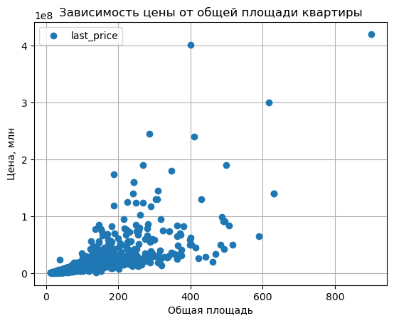

```python
data.pivot_table(index='total_area', values='last_price').plot(style='o', grid=True)
plt.title('Зависимость цены от общей площади квартиры')
plt.ylabel('Цена, млн')
plt.xlabel('Общая площадь')
plt.show()
```

```python
print('Корреляция Пирсона:', data['total_area'].corr(data['last_price']))
```

```
Корреляция Пирсона: 0.7026130576480748
```

- Чем больше площадь - тем больше цена.

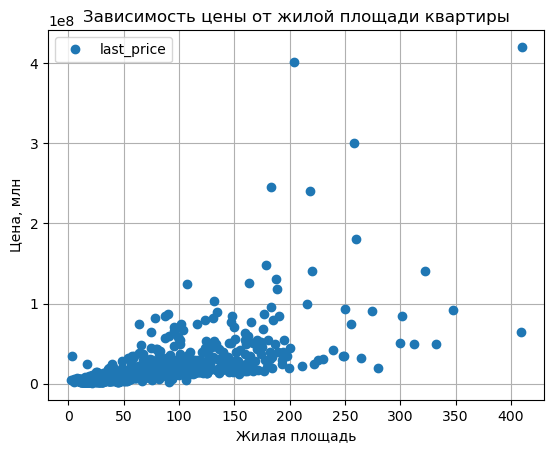

```python
data.pivot_table(index='living_area', values='last_price').plot(style='o', grid=True)
plt.title('Зависимость цены от жилой площади квартиры')
plt.ylabel('Цена, млн')
plt.xlabel('Жилая площадь')
plt.show()
```

```python
print('Корреляция Пирсона:', data['living_area'].corr(data['last_price']))
```

```
Корреляция Пирсона: 0.5917441802461607
```

- Жилая площадь тоже конечно сильно влияет на цену.

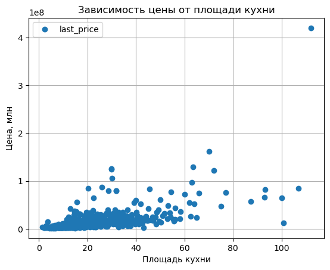

```python
data.pivot_table(index='kitchen_area', values='last_price').plot(style='o', grid=True)
plt.title('Зависимость цены от площади кухни')
plt.ylabel('Цена, млн')
plt.xlabel('Площадь кухни')
plt.show()
```

```python
print('Корреляция Пирсона:', data['kitchen_area'].corr(data['last_price']))
```

```
Корреляция Пирсона: 0.4951777809485292
```

- Площадь кухни в меньшей степени оказывает влияение на цену.

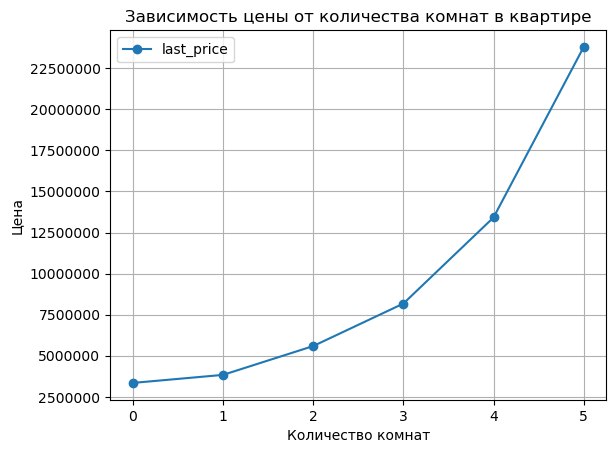

```python
data.query('rooms <= 5').pivot_table(index='rooms', values='last_price').plot(style='o-', grid=True)
plt.ticklabel_format(useOffset=False, style='plain');
plt.title('Зависимость цены от количества комнат в квартире')
plt.ylabel('Цена')
plt.xlabel('Количество комнат')
plt.show()
```

```python
print('Корреляция Пирсона:', data['rooms'].corr(data['last_price']))
```

```
Корреляция Пирсона: 0.3921806648355889
```

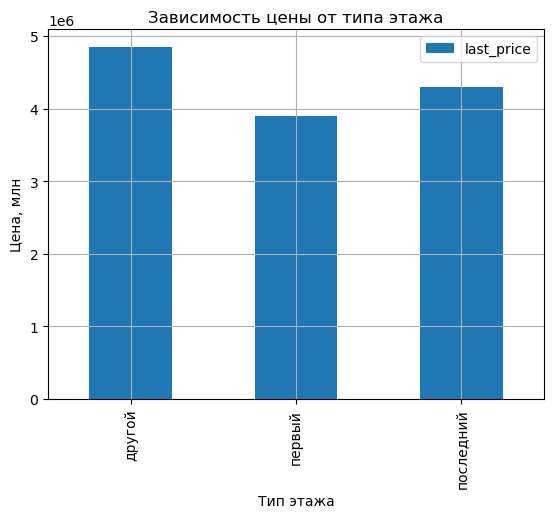

```python
data.pivot_table(index='floor_type', values='last_price', aggfunc='median').plot(kind='bar', grid=True)
plt.title('Зависимость цены от типа этажа')
plt.ylabel('Цена, млн')
plt.xlabel('Тип этажа')
plt.show()
```

- Квартиры на первом этаже самые дешёвые. На последнем этаже цена тоже ниже, чем в других.

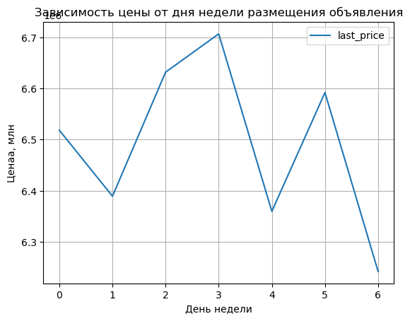

```python
data.pivot_table(index='weekday_exposition', values='last_price').plot(grid=True)
plt.title('Зависимость цены от дня недели размещения объявления')
plt.ylabel('Ценаа, млн')
plt.xlabel('День недели')
plt.show()
```

- В объявлениях, размещённых в среду, четверг и субботу - самые высокие цены.

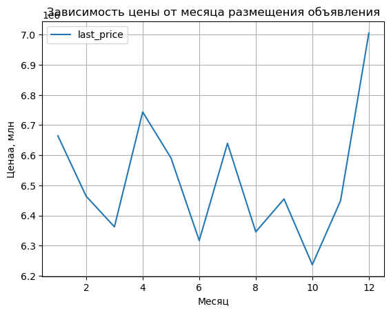

```python
data.pivot_table(index='month_exposition', values='last_price').plot(grid=True)
plt.title('Зависимость цены от месяца размещения объявления')
plt.ylabel('Ценаа, млн')
plt.xlabel('Месяц')
plt.show()
```

- Также не стоит ждать новогодних скидок: в декабре цены на квартиры бьют рекорды.

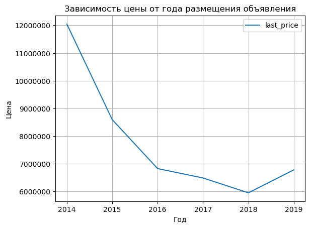

```python
data.pivot_table(index='year_exposition', values='last_price').plot(grid=True)
plt.ticklabel_format(useOffset=False, style='plain');
plt.title('Зависимость цены от года размещения объявления')
plt.ylabel('Цена')
plt.xlabel('Год')
plt.show()
```

- В последнем же графике видим как обрушился рынок в 2014-ом году и постепенно падал вплоть до 2018-го.

### Средняя цена одного квадратного метра в 10 населённых пунктах с наибольшим числом объявлений

Топ-10 локаций по количеству объявлений

```python
locations = data.pivot_table(index='locality_name', values='square_price', aggfunc=['count', 'median']).reset_index()
locations.columns = ['локация', 'всего объявлений', 'средняя цена']
locations['средняя цена'] = locations['средняя цена'].astype(int)
locations.sort_values(by='всего объявлений', ascending=False).reset_index(drop=True).head(10)
```

|  | локация | всего объявлений | средняя цена |
| --- | --- | --- | --- |
| 0 | Санкт-Петербург | 15649 | 104774 |
| 1 | Мурино | 586 | 86250 |
| 2 | Кудрово | 470 | 95555 |
| 3 | Шушары | 439 | 76829 |
| 4 | Всеволожск | 398 | 65789 |
| 5 | Пушкин | 369 | 100000 |
| 6 | Колпино | 338 | 74723 |
| 7 | Парголово | 327 | 91642 |
| 8 | Гатчина | 307 | 67796 |
| 9 | Выборг | 237 | 58158 |

- Подавляющее большинство объявлений - с продажей недвижимости в самом Санкт-Петербурге, а не области.

Топ-10 с самой высокой стоимостью квадратного метра

```python
locations.sort_values(by='средняя цена', ascending=False).reset_index(drop=True).head(10)
```

|  | локация | всего объявлений | средняя цена |
| --- | --- | --- | --- |
| 0 | Санкт-Петербург | 15649 | 104774 |
| 1 | Зеленогорск | 24 | 101666 |
| 2 | Пушкин | 369 | 100000 |
| 3 | Сестрорецк | 183 | 99678 |
| 4 | Левашово | 1 | 96997 |
| 5 | Кудрово | 470 | 95555 |
| 6 | Парголово | 327 | 91642 |
| 7 | Мистолово | 11 | 90888 |
| 8 | Стрельна | 43 | 87254 |
| 9 | Репино | 4 | 86542 |

Топ-10 с самой низкой стоимостью квадратного метра

```python
locations.sort_values(by='средняя цена').reset_index(drop=True).head(10)
```

|  | локация | всего объявлений | средняя цена |
| --- | --- | --- | --- |
| 0 | Старополье | 3 | 11000 |
| 1 | Свирь | 2 | 11481 |
| 2 | Вахнова Кара | 1 | 11688 |
| 3 | Выскатка | 2 | 12335 |
| 4 | Совхозный | 2 | 12629 |
| 5 | Малая Романовка | 1 | 12724 |
| 6 | Тесово-4 | 1 | 12931 |
| 7 | Сижно | 1 | 13709 |
| 8 | Ям-Тесово | 2 | 13711 |
| 9 | Житково | 2 | 14956 |

Топ-10 с самой низкой стоимостью квадратного метра, но с количеством объявлений от 100

```python
locations[locations['всего объявлений'] > 100].sort_values(by='средняя цена').reset_index(drop=True).head(10)
```

|  | локация | всего объявлений | средняя цена |
| --- | --- | --- | --- |
| 0 | Сланцы | 112 | 18254 |
| 1 | Волхов | 111 | 35000 |
| 2 | Кириши | 125 | 37962 |
| 3 | Кингисепп | 104 | 46770 |
| 4 | Тосно | 104 | 58016 |
| 5 | Выборг | 237 | 58158 |
| 6 | Всеволожск | 398 | 65789 |
| 7 | Сертолово | 142 | 67588 |
| 8 | Гатчина | 307 | 67796 |
| 9 | Красное Село | 176 | 71849 |

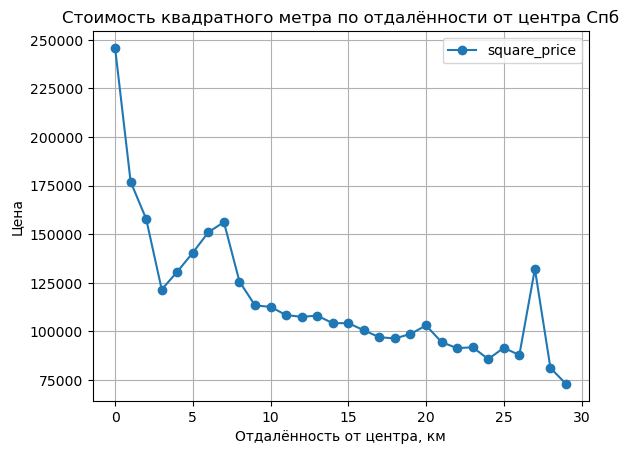

```python
spb = data[data['locality_name'] == 'Санкт-Петербург']
spb.pivot_table(index='cityCenters_km', values='square_price').reset_index()\
    .plot(x='cityCenters_km', y='square_price', style='o-', grid=True)
plt.title('Стоимость квадратного метра по отдалённости от центра Спб')
plt.ylabel('Цена')
plt.xlabel('Отдалённость от центра, км')
plt.show()
```

- На последнем графике мы видим стандартную историю для большинства городов: чем ближе центр - тем дороже квадратный метр.